# NLP Course Project

```
                                                                                          - Varanasi Abhishek Bharadwaj
```

## **Problem Statement**

### Business Context

The prices of the stocks of companies listed under a global exchange are influenced by a variety of factors, with the company's financial performance, innovations and collaborations, and market sentiment being factors that play a significant role. News and media reports can rapidly affect investor perceptions and, consequently, stock prices in the highly competitive financial industry. With the sheer volume of news and opinions from a wide variety of sources, investors and financial analysts often struggle to stay updated and accurately interpret its impact on the market. As a result, investment firms need sophisticated tools to analyze market sentiment and integrate this information into their investment strategies.

### Problem Definition

With an ever-rising number of news articles and opinions, an investment startup aims to leverage artificial intelligence to address the challenge of interpreting stock-related news and its impact on stock prices. They have collected historical daily news for a specific company listed under NASDAQ, along with data on its daily stock price and trade volumes.

As a member of the Data Science and AI team in the startup, you have been tasked with analyzing the data, developing an AI-driven sentiment analysis system that will automatically process and analyze news articles to gauge market sentiment, and summarizing the news at a weekly level to enhance the accuracy of their stock price predictions and optimize investment strategies. This will empower their financial analysts with actionable insights, leading to more informed investment decisions and improved client outcomes.

### Data Dictionary

- `Date` : The date the news was released
- `News` : The content of news articles that could potentially affect the company's stock price
- `Open` : The stock price (in \$) at the beginning of the day
- `High` : The highest stock price (in \$) reached during the day
- `Low` : The lowest stock price (in \$) reached during the day
- `Close` : The adjusted stock price (in \$) at the end of the day
- `Volume` : The number of shares traded during the day
- `Label` : The sentiment polarity of the news content
  - 1: positive
  - 0: neutral
  - -1: negative

Note: I ran the Weekly news summarization part (Part 2) first on colab and then the EDA & sentiment analysis part (Part 1) next locally. I did this because not using GPU for a certain amount of time is leading to runtime disconnect on colab.

# Part 1

## **Installing and Importing Necessary Libraries**

```python
# installing the sentence-transformers and gensim libraries for word embeddings
!pip install -U sentence-transformers gensim transformers tqdm -q
```

[output not shown]

## **Loading the dataset**

```python
import pandas as pd
import numpy as np
import os
import re
import gensim

df = pd.read_csv("stock_news.csv")
```

## **Data Overview**

```python
df.head()
```

|  | Date | News | Open | High | Low | Close | Volume | Label |
| --- | --- | --- | --- | --- | --- | --- | --- | --- |
| 0 | 2019-01-02 | The tech sector experienced a significant dec... | 41.740002 | 42.244999 | 41.482498 | 40.246914 | 130672400 | -1 |
| 1 | 2019-01-02 | Apple lowered its fiscal Q1 revenue guidance ... | 41.740002 | 42.244999 | 41.482498 | 40.246914 | 130672400 | -1 |
| 2 | 2019-01-02 | Apple cut its fiscal first quarter revenue fo... | 41.740002 | 42.244999 | 41.482498 | 40.246914 | 130672400 | -1 |
| 3 | 2019-01-02 | This news article reports that yields on long... | 41.740002 | 42.244999 | 41.482498 | 40.246914 | 130672400 | -1 |
| 4 | 2019-01-02 | Apple's revenue warning led to a decline in U... | 41.740002 | 42.244999 | 41.482498 | 40.246914 | 130672400 | -1 |

```python
df.info()
```

```
<class 'pandas.core.frame.DataFrame'>
RangeIndex: 349 entries, 0 to 348
Data columns (total 8 columns):
 #   Column  Non-Null Count  Dtype
---  ------  --------------  -----
 0   Date    349 non-null    object
 1   News    349 non-null    object
 2   Open    349 non-null    float64
 3   High    349 non-null    float64
 4   Low     349 non-null    float64
 5   Close   349 non-null    float64
 6   Volume  349 non-null    int64
 7   Label   349 non-null    int64
dtypes: float64(4), int64(2), object(2)
memory usage: 21.9+ KB
```

## **Exploratory Data Analysis**

### Univariate Analysis

- Distribution of individual variables
- Compute and check the distribution of the length of news content

```python
import matplotlib.pyplot as plt
import seaborn as sns
```

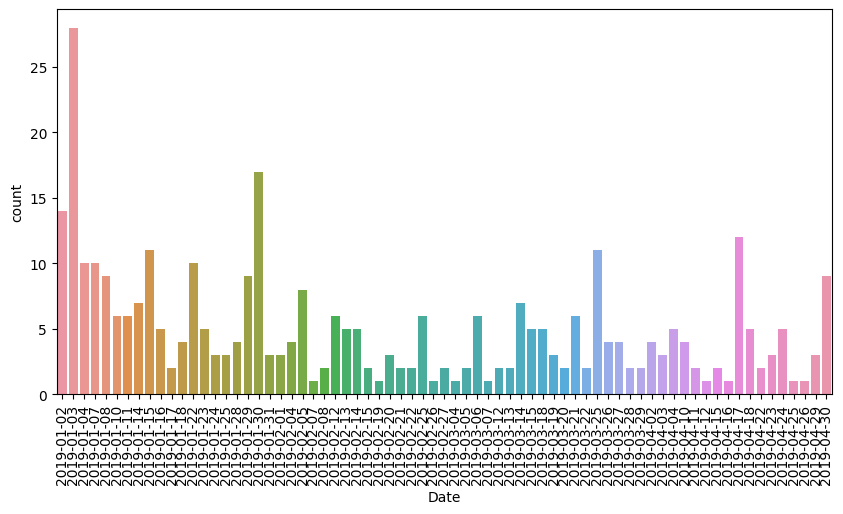

```python
plt.figure(figsize=(10, 5))
sns.countplot(data = df, x = 'Date')
plt.xticks(rotation = 90)
plt.show()
```

The news release activity is highly uneven across dates. A significant spike at the beginning with the highest number of news releases were on 2019-01-03 suggests a concentrated number of releases on that date, possibly due to a major event or deadline. While there are sporadic peaks on other dates, the majority of dates exhibit relatively low release counts, reflecting a long tail of infrequent activity. This uneven distribution suggests that releases are clustered around specific periods, likely influenced by organizational schedules, milestones, or seasonal factors.

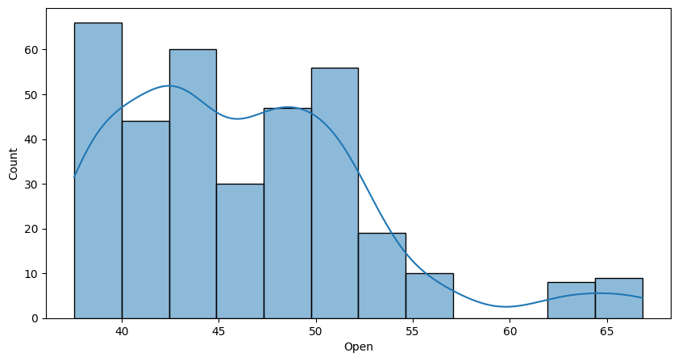

```python
plt.figure(figsize=(10, 5))
sns.histplot(data = df, x = 'Open', kde=True)
plt.xticks(rotation = 0)
plt.show()
```

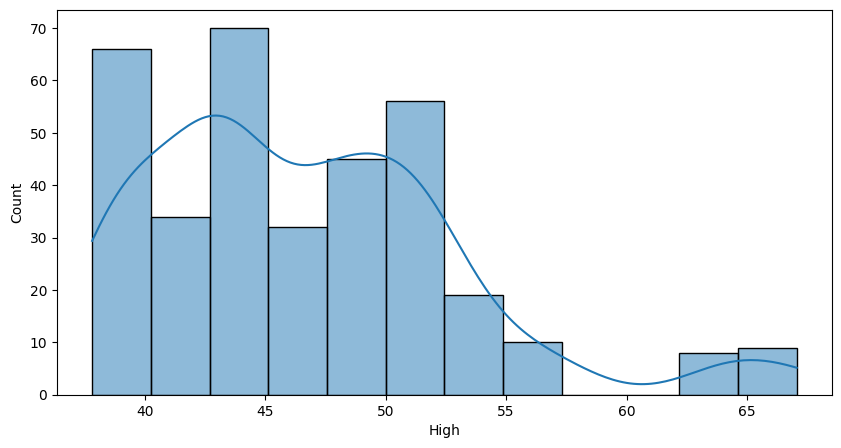

```python
plt.figure(figsize=(10, 5))
sns.histplot(data = df, x = 'High', kde=True)
plt.xticks(rotation = 0)
plt.show()
```

This plot shows the distribution of the variable "High," which is moderately right-skewed, with most values concentrated between 40 and 55. The highest frequency occurs in the 42.5–45 range, indicating that this is the most common range for the "High" variable. The distribution gradually tapers off beyond 55, with relatively few occurrences around 65. The smooth density curve highlights peaks near 42.5–45 and 50, suggesting potential clustering in these intervals. Overall, the data indicates a concentration of lower "High" values with a long tail toward higher values.

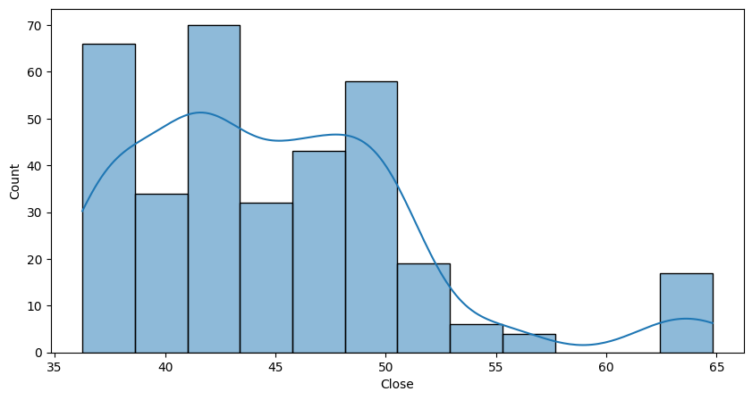

```python
plt.figure(figsize=(10, 5))
sns.histplot(data = df, x = 'Close', kde=True)
plt.xticks(rotation = 0)
plt.show()
```

This plot shows the distribution of the variable "Close," which is moderately right-skewed, with most values concentrated between 40 and 50. The highest frequency occurs around 42.5, indicating that this is the most common range for the "Close" variable. The distribution gradually tapers off beyond 50, with relatively few occurrences in the range of 62.5-65 . The smooth density curve highlights peaks at 35-40, 42.5 and 50, suggesting potential clustering in these regions. Overall, the data indicates a concentration of lower "Close" values with a long tail toward higher values.

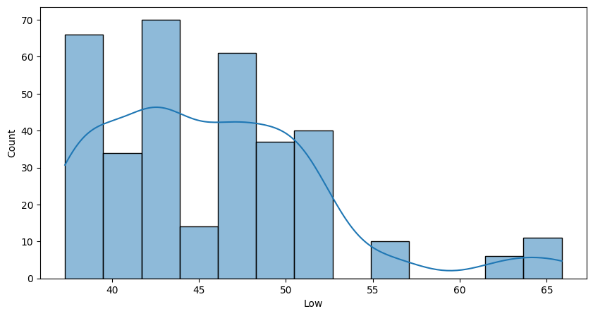

```python
plt.figure(figsize=(10, 5))
sns.histplot(data = df, x = 'Low', kde=True)
plt.xticks(rotation = 0)
plt.show()
```

This plot shows the distribution of the variable "Low," which is moderately right-skewed, with most values concentrated between 40 and 50. The highest frequency occurs around 42.5, indicating that this is the most common range for the "Low" variable. The distribution gradually tapers off beyond 50, with relatively few occurrences at 55 and in the range of 62.5-65. The smooth density curve highlights peaks below 40, around 42.5 and around 47.5, suggesting potential clustering in these regions. Overall, the data indicates a concentration of lower "Low" values with a long tail toward higher values.

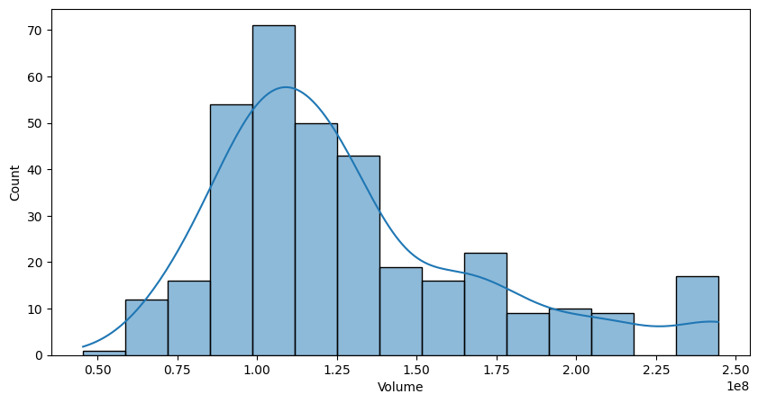

```python
plt.figure(figsize=(10, 5))
sns.histplot(data = df, x = 'Volume', kde=True)
plt.xticks(rotation = 0)
plt.show()
```

The distribution of the variale Volume is very close to normal with a slight skweness to the right. The highest frequesncy occurs around 1e8. The distrbution tappers off beyond 2e8 with a few values between 2.25e8. Overall, this variable has only one significant peak at 1e8 suggesting a cluster around that value.

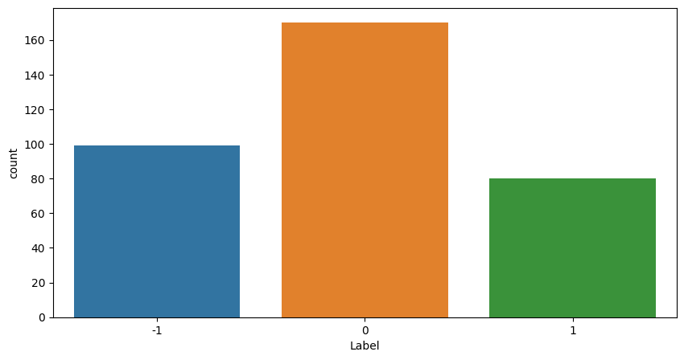

```python
plt.figure(figsize=(10, 5))
sns.countplot(data = df, x = 'Label')
plt.xticks(rotation = 0)
plt.show()
```

Label 0 has the highest count with label 1 having the least count. The above also suggests that there is a class imbalance in this column.

```python
df['news_length'] = df['News'].apply(lambda x: len(x.split()))
```

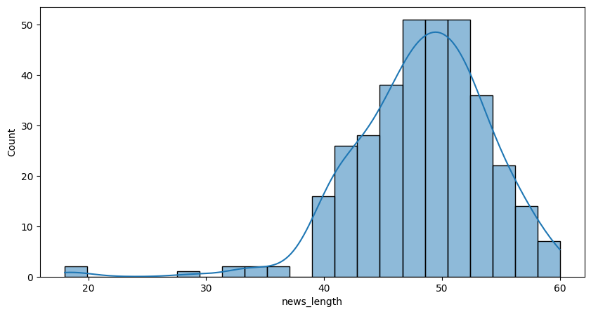

```python
plt.figure(figsize=(10, 5))
sns.histplot(data = df, x = 'news_length', kde=True)
plt.xticks(rotation = 0)
plt.show()
```

The distrbution of the new lengths is close to normal distribution in the range of 40-60 with a very long tail below 40 suggesting that the overall distribution is left-skewed. The highest frequency is at the length 50 and also it is the only peak of this distribution suggesting a cluster of news texts with this length.

```python
df.drop(['news_length'], axis = 1, inplace = True)
```

### Bivariate Analysis

- Correlation
- Sentiment Polarity vs Price
- Date vs Price

**Note**: The above points are listed to provide guidance on how to approach bivariate analysis. Analysis has to be done beyond the above listed points to get maximum scores.

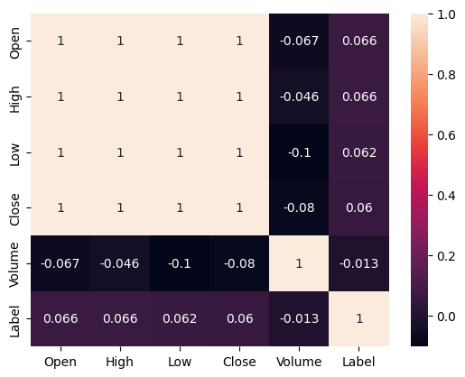

```python
sns.heatmap(df.drop(['Date', 'News'], axis = 1).corr(), annot=True)
```

The stock prices 'Close', 'Low', 'High', 'Open' have a very high correlation (equal to 1) while the rest of the features don't have significant correlation. The target variable 'Label' has less than 0.1 correlation with all the other numerical columns.

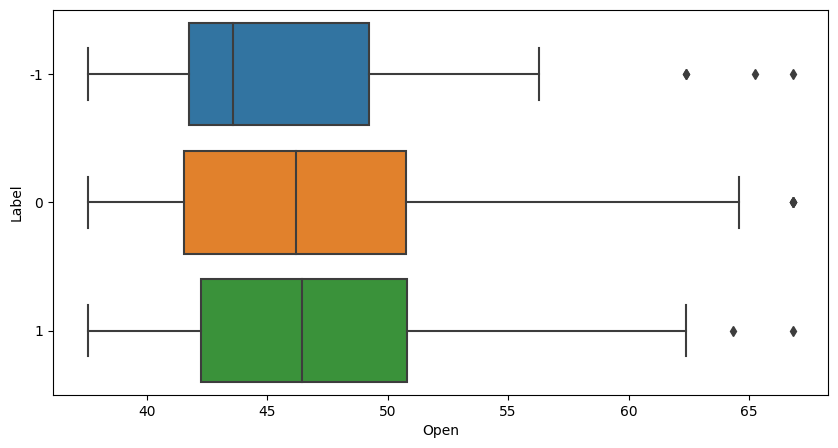

```python
plt.figure(figsize=(10, 5))
sns.boxplot(data = df, x = 'Open', y = 'Label', orient="h")
plt.xticks(rotation = 0)
plt.show()
```

1. The distribution for label -1 is heavily right-skewed with 3 outliers on the right tail.
2. The distrbution for label 0 is right-skewed with 1 outlier on the right tail.
3. Teh distribution for label 1 is slightly right-skewed with 2 outliers on th right tail.

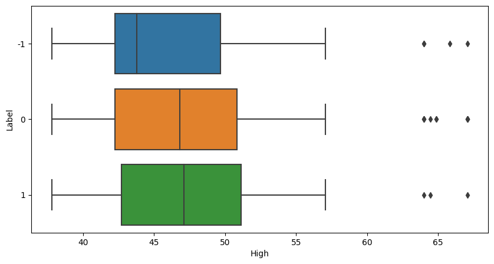

```python
plt.figure(figsize=(10, 5))
sns.boxplot(data = df, x = 'High', y = 'Label', orient="h")
plt.xticks(rotation = 0)
plt.show()
```

1. The distribution for label -1 is heavily right-skewed with 3 outliers on the right tail.
2. The distrbution for label 0 is very slightly skewed to the right since the right whisker is a little longer the left whisker with 4 outliers on the right tail.
3. The distribution for label 1 is close to normal distrbution since the whisker lengths are almost the same. It has 3 outliers towards the right whisker.

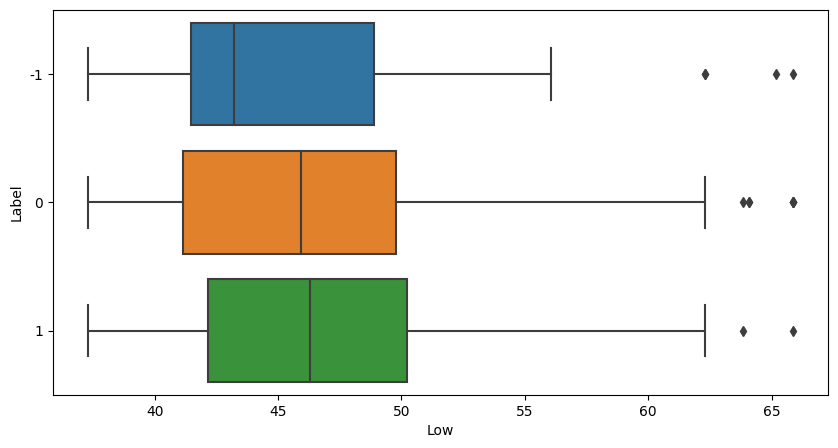

```python
plt.figure(figsize=(10, 5))
sns.boxplot(data = df, x = 'Low', y = 'Label', orient="h")
plt.xticks(rotation = 0)
plt.show()
```

1. The distribution for label -1 is heavily right-skewed with 3 outliers on the right tail.
2. The distrbution for label 0 is right-skewed with 3 outliers on the right tail.
3. The distrbution for label 1 is right-skewed with 2 outliers on the right tail.

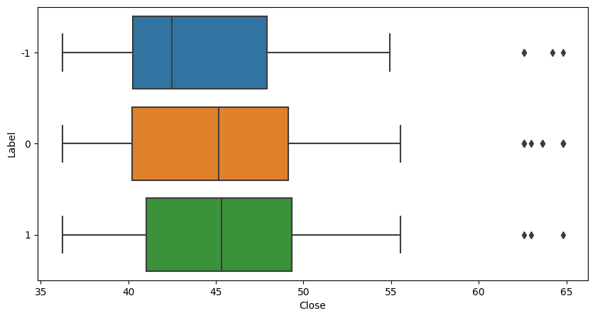

```python
plt.figure(figsize=(10, 5))
sns.boxplot(data = df, x = 'Close', y = 'Label', orient="h")
plt.xticks(rotation = 0)
plt.show()
```

1. The distribution for label -1 is right-skewed with 3 outliers on the right tail.
2. The distrbution for label 0 is slightly right-skewed with 4 outliers on the right tail.
3. The distrbution for label 1 is close to normal distribution with 3 outliers on the right tail.

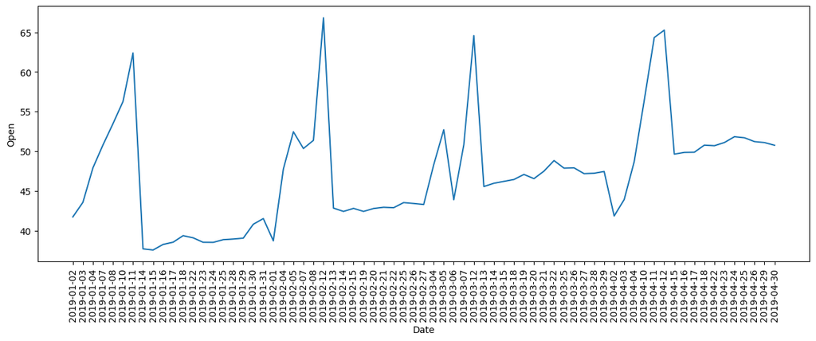

```python
plt.figure(figsize=(15, 5))
sns.lineplot(data = df, x = 'Date', y = 'Open')
plt.xticks(rotation = 90)
plt.show()
```

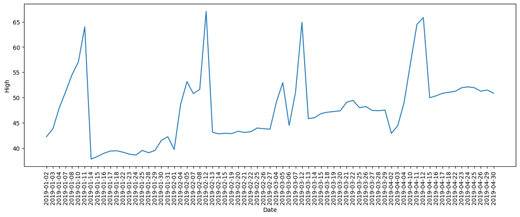

```python
plt.figure(figsize=(15, 5))
sns.lineplot(data = df, x = 'Date', y = 'High')
plt.xticks(rotation = 90)
plt.show()
```

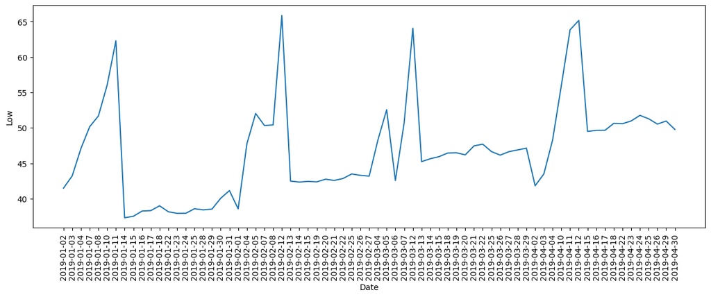

```python
plt.figure(figsize=(15, 5))
sns.lineplot(data = df, x = 'Date', y = 'Low')
plt.xticks(rotation = 90)
plt.show()
```

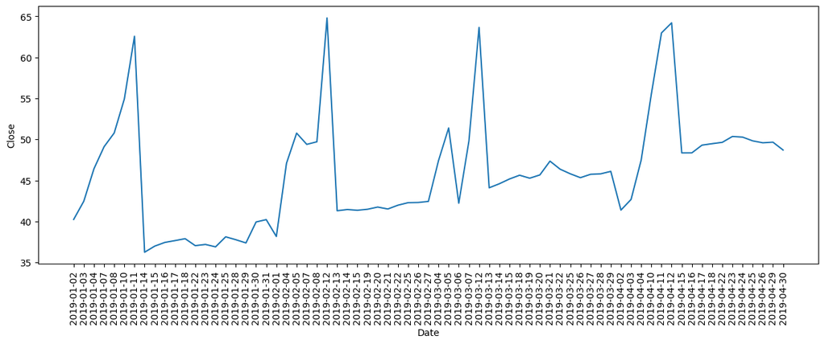

```python
plt.figure(figsize=(15, 5))
sns.lineplot(data = df, x = 'Date', y = 'Close')
plt.xticks(rotation = 90)
plt.show()
```

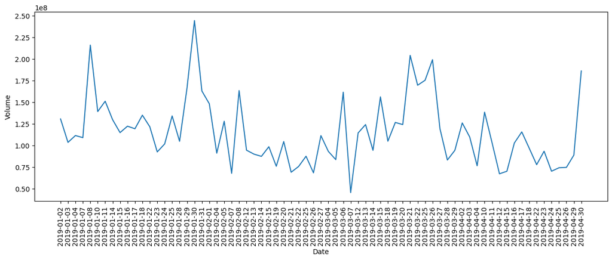

```python
plt.figure(figsize=(15, 5))
sns.lineplot(data = df, x = 'Date', y = 'Volume')
plt.xticks(rotation = 90)
plt.show()
```

The above five line-plots shows the variables "Open", "High", "Low", "Close" & "Volume" fluctuating significantly over time, with sharp peaks and steep drops indicating high volatility. These irregular spikes suggest that the changes are event-driven rather than periodic.

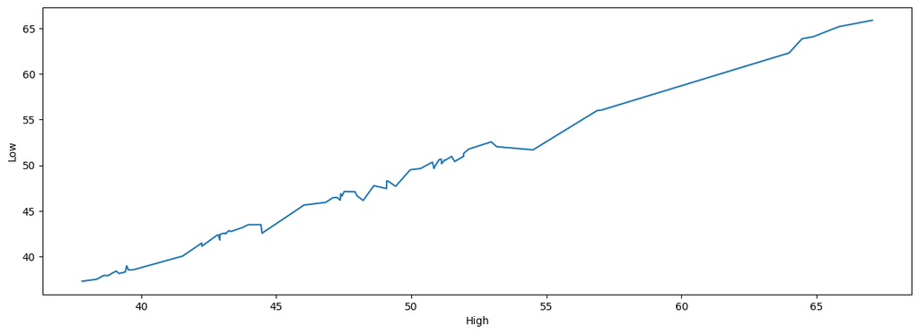

```python
plt.figure(figsize=(15, 5))
sns.lineplot(data = df, x = 'High', y = 'Low')
plt.xticks(rotation = 0)
plt.show()
```

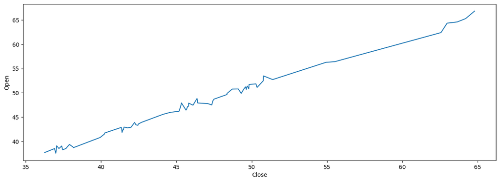

```python
plt.figure(figsize=(15, 5))
sns.lineplot(data = df, x = 'Close', y = 'Open')
plt.xticks(rotation = 0)
plt.show()
```

The above plots of "Low" vs "High" and "Close" vs "Open" show an almost linear correlation agreeing with the correlation values from the correlation heatmap.

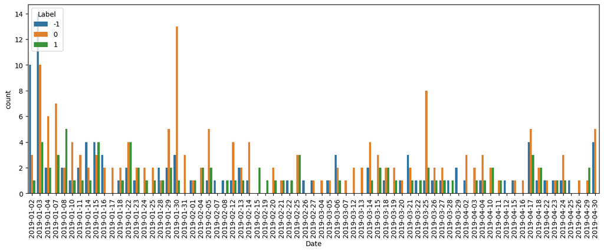

```python
plt.figure(figsize=(15, 5))
sns.countplot(data = df, x = 'Date', hue = 'Label')
plt.xticks(rotation = 90)
plt.show()
```

1. 2019-01-30 has the highest count of news releases with neutral sentiment.
2. 2019-01-03 has the highest count of news releases with negative sentiment.
3. 2019-01-08 has the highest count of news releases with positive sentiment.
4. The frequency of news releases is very high in the month of January with this count suddenly dropping from February.
5. The count picked from the end of March with most of the news releases having neutral sentiment in the months of March and April among the traders and public.

## **Data Preprocessing**

```python
df.duplicated().sum()
```

```
0
```

No duplicate rows.

```python
import nltk
nltk.download('stopwords')
nltk.download('wordnet')

from nltk.corpus import stopwords
from nltk.stem.porter import PorterStemmer
import re
```

For sentiment analysis, we should consider the columns 'News' and 'Label' as the other columns are not directly needed for sentiment task itself. However, these stock price columns come into play when you're interpreting the impact of news sentiment on stock prices beyond stock prediction.

```python
# defining a function to remove special characters
def remove_special_characters(text):
    # Defining the regex pattern to match non-alphanumeric characters
    pattern = '[^A-Za-z0-9]+'

    # Finding the specified pattern and replacing non-alphanumeric characters with a blank string
    new_text = ''.join(re.sub(pattern, ' ', text))

    return new_text

# defining a function to remove stop words using the NLTK library
def remove_stopwords(text):
    # Split text into separate words
    words = text.split()

    # Removing English language stopwords
    new_text = ' '.join([word for word in words if word not in stopwords.words('english')])

    return new_text

ps = PorterStemmer()
# defining a function to perform stemming
def apply_porter_stemmer(text):
    # Split text into separate words
    words = text.split()

    # Applying the Porter Stemmer on every word of a message and joining the stemmed words back into a single string
    new_text = ' '.join([ps.stem(word) for word in words])

    return new_text
```

```python
# Applying the function to remove special characters
df['cleaned_text'] = df['News'].apply(remove_special_characters)
df['cleaned_text'] = df['cleaned_text'].str.lower()
df['cleaned_text'] = df['cleaned_text'].str.strip()
df['cleaned_text_without_stopwords'] = df['cleaned_text'].apply(remove_stopwords)
df['final_cleaned_text'] = df['cleaned_text_without_stopwords'].apply(apply_porter_stemmer)
```

```python
X = df['final_cleaned_text']
y = df['Label']
```

```python
from sklearn.model_selection import train_test_split

X_train, X_test, y_train, y_test = train_test_split(X, y, test_size = 0.2, stratify = y, random_state = 42)
```

```python
X_train, X_val, y_train, y_val = train_test_split(X_train, y_train, test_size = 0.1, stratify = y_train, random_state = 42)
```

```python
X_train = X_train.reset_index(drop = True)
X_test = X_test.reset_index(drop = True)
X_val = X_val.reset_index(drop = True)
y_train = y_train.reset_index(drop = True)
y_test = y_test.reset_index(drop = True)
y_val = y_val.reset_index(drop = True)
```

```python
print(X_train.shape)
print(y_train.shape)
print(X_test.shape)
print(y_test.shape)
print(X_val.shape)
print(y_val.shape)
```

```
(251,)
(251,)
(70,)
(70,)
(28,)
(28,)
```

## **Word Embeddings**

### Word2Vec

```python
# Creating a list of all words in our data
from gensim.models import Word2Vec
words_list = [item.split(" ") for item in df['final_cleaned_text'].values]
```

```python
vec_size = 300
model_W2V = Word2Vec(words_list, vector_size = vec_size, min_count = 1, window=5, workers = 6)
```

```python
print("Length of the vocabulary is", len(list(model_W2V.wv.key_to_index)))
```

```
Length of the vocabulary is 2580
```

```python
# Retrieving the words present in the Word2Vec model's vocabulary
words = list(model_W2V.wv.key_to_index.keys())

# Retrieving word vectors for all the words present in the model's vocabulary
wvs = model_W2V.wv[words].tolist()

# Creating a dictionary of words and their corresponding vectors
word_vector_dict = dict(zip(words, wvs))
```

```python
def average_vectorizer_Word2Vec(doc):
    # Initializing a feature vector for the sentence
    feature_vector = np.zeros((vec_size,), dtype="float64")

    # Creating a list of words in the sentence that are present in the model vocabulary
    words_in_vocab = [word for word in doc.split() if word in words]

    # adding the vector representations of the words
    for word in words_in_vocab:
        feature_vector += np.array(word_vector_dict[word])

    # Dividing by the number of words to get the average vector
    if len(words_in_vocab) != 0:
        feature_vector /= len(words_in_vocab)

    return feature_vector
```

```python
# creating a dataframe of the vectorized documents
X_train_Word2Vec = pd.DataFrame(X_train.apply(average_vectorizer_Word2Vec).tolist(), columns=['Feature '+str(i) for i in range(vec_size)])
X_train_Word2Vec
```

|  | Feature 0 | Feature 1 | Feature 2 | Feature 3 | Feature 4 | Feature 5 | Feature 6 | Feature 7 | Feature 8 | Feature 9 | ... | Feature 290 | Feature 291 | Feature 292 | Feature 293 | Feature 294 | Feature 295 | Feature 296 | Feature 297 | Feature 298 | Feature 299 |
| --- | --- | --- | --- | --- | --- | --- | --- | --- | --- | --- | --- | --- | --- | --- | --- | --- | --- | --- | --- | --- | --- |
| 0 | 0.000592 | 0.002806 | -0.000286 | 0.001768 | -0.000547 | -0.004408 | 0.002361 | 0.006378 | 0.001332 | -0.000727 | ... | 0.000443 | 0.004679 | 0.003757 | 0.000492 | 0.003948 | 0.003730 | 0.000416 | -0.002454 | 0.003352 | 0.000155 |
| 1 | -0.000462 | 0.003149 | -0.000536 | 0.001709 | -0.000327 | -0.002821 | 0.001741 | 0.004941 | 0.000702 | -0.001009 | ... | -0.000155 | 0.003403 | 0.002659 | -0.000301 | 0.002243 | 0.003207 | 0.000769 | -0.000822 | 0.001522 | 0.000018 |
| 2 | 0.000354 | 0.001651 | 0.000052 | 0.001454 | 0.000231 | -0.003368 | 0.001173 | 0.005506 | 0.001192 | -0.000381 | ... | 0.000435 | 0.003262 | 0.002489 | 0.000516 | 0.002430 | 0.003303 | 0.000795 | -0.001873 | 0.002445 | 0.000115 |
| 3 | -0.000102 | 0.002248 | -0.001172 | 0.001601 | -0.000185 | -0.003681 | 0.001802 | 0.004944 | 0.001621 | -0.000462 | ... | -0.000324 | 0.003808 | 0.002382 | 0.000840 | 0.003126 | 0.002694 | 0.000172 | -0.002156 | 0.001545 | -0.000055 |
| 4 | 0.000062 | 0.005110 | -0.001074 | 0.002505 | 0.000076 | -0.007364 | 0.004276 | 0.010848 | 0.002857 | -0.001086 | ... | 0.000440 | 0.008166 | 0.005741 | 0.000385 | 0.004888 | 0.006161 | 0.001396 | -0.003636 | 0.003992 | -0.000118 |
| ... | ... | ... | ... | ... | ... | ... | ... | ... | ... | ... | ... | ... | ... | ... | ... | ... | ... | ... | ... | ... | ... |
| 246 | 0.000310 | 0.002073 | -0.000655 | 0.001159 | -0.000605 | -0.002126 | 0.001324 | 0.002467 | 0.000672 | -0.000102 | ... | -0.000144 | 0.002376 | 0.001605 | -0.000080 | 0.002122 | 0.000912 | -0.000291 | -0.001172 | 0.001209 | -0.000054 |
| 247 | -0.000986 | 0.000783 | -0.000567 | 0.000707 | 0.000201 | -0.001117 | 0.000659 | 0.002110 | 0.000671 | 0.000399 | ... | -0.000452 | 0.001570 | 0.000990 | 0.000197 | 0.001245 | 0.001182 | -0.000295 | -0.001066 | 0.001124 | -0.000161 |
| 248 | 0.000242 | 0.003127 | 0.000265 | 0.001877 | 0.000416 | -0.003904 | 0.001811 | 0.006659 | 0.001566 | -0.001105 | ... | 0.000511 | 0.003720 | 0.003430 | -0.000404 | 0.002993 | 0.003987 | 0.000716 | -0.002044 | 0.002833 | -0.000182 |
| 249 | -0.000077 | 0.003379 | -0.000777 | 0.001899 | -0.000746 | -0.003713 | 0.001853 | 0.006371 | 0.001755 | -0.000631 | ... | -0.000325 | 0.004504 | 0.003095 | 0.000538 | 0.002822 | 0.004066 | 0.000757 | -0.002564 | 0.002755 | -0.000007 |
| 250 | -0.000067 | 0.003907 | -0.000284 | 0.002112 | 0.000079 | -0.004899 | 0.001754 | 0.007869 | 0.001293 | -0.000806 | ... | 0.000386 | 0.005418 | 0.004146 | -0.000088 | 0.003892 | 0.003581 | 0.000237 | -0.003241 | 0.003293 | -0.000585 |

251 rows × 300 columns

```python
# creating a dataframe of the vectorized documents
X_test_Word2Vec = pd.DataFrame(X_test.apply(average_vectorizer_Word2Vec).tolist(), columns=['Feature '+str(i) for i in range(vec_size)])
X_test_Word2Vec
```

|  | Feature 0 | Feature 1 | Feature 2 | Feature 3 | Feature 4 | Feature 5 | Feature 6 | Feature 7 | Feature 8 | Feature 9 | ... | Feature 290 | Feature 291 | Feature 292 | Feature 293 | Feature 294 | Feature 295 | Feature 296 | Feature 297 | Feature 298 | Feature 299 |
| --- | --- | --- | --- | --- | --- | --- | --- | --- | --- | --- | --- | --- | --- | --- | --- | --- | --- | --- | --- | --- | --- |
| 0 | 0.000573 | 0.002755 | -0.000573 | 0.001307 | 0.000163 | -0.004143 | 0.002022 | 0.006191 | 0.001822 | -0.000759 | ... | 0.000191 | 0.004407 | 0.003511 | 0.000772 | 0.002824 | 0.003512 | 0.000393 | -0.001755 | 0.002730 | -0.000409 |
| 1 | 0.000777 | 0.005644 | -0.001069 | 0.003472 | 0.000080 | -0.006740 | 0.003159 | 0.010726 | 0.002691 | -0.000698 | ... | -0.000087 | 0.007556 | 0.004902 | 0.000701 | 0.005078 | 0.006531 | 0.000776 | -0.003566 | 0.003839 | -0.000182 |
| 2 | -0.000095 | 0.003619 | -0.000697 | 0.002008 | -0.000298 | -0.004522 | 0.001833 | 0.007225 | 0.001192 | -0.000450 | ... | -0.000533 | 0.004147 | 0.003339 | 0.000039 | 0.002908 | 0.004394 | 0.001012 | -0.002376 | 0.002299 | 0.000263 |
| 3 | 0.000665 | 0.004935 | -0.001286 | 0.003482 | -0.000813 | -0.006652 | 0.003195 | 0.009771 | 0.002465 | -0.000937 | ... | -0.000782 | 0.007275 | 0.005246 | 0.000072 | 0.005022 | 0.006371 | 0.000992 | -0.002657 | 0.004022 | 0.000124 |
| 4 | -0.000361 | 0.003885 | -0.000518 | 0.002241 | -0.000023 | -0.006148 | 0.002744 | 0.009312 | 0.001377 | -0.001038 | ... | 0.000022 | 0.006739 | 0.005094 | 0.001221 | 0.004538 | 0.005423 | 0.000494 | -0.002837 | 0.003339 | 0.000324 |
| ... | ... | ... | ... | ... | ... | ... | ... | ... | ... | ... | ... | ... | ... | ... | ... | ... | ... | ... | ... | ... | ... |
| 65 | 0.000162 | 0.005232 | -0.000430 | 0.002617 | -0.000072 | -0.006731 | 0.004154 | 0.010946 | 0.001859 | -0.001280 | ... | -0.000097 | 0.008071 | 0.005628 | 0.000565 | 0.004779 | 0.007154 | 0.000652 | -0.003058 | 0.005058 | 0.000086 |
| 66 | 0.000095 | 0.003235 | -0.000920 | 0.001683 | 0.000730 | -0.004312 | 0.002309 | 0.006653 | 0.001263 | -0.000761 | ... | -0.000305 | 0.003985 | 0.003216 | 0.000369 | 0.002598 | 0.003744 | 0.000523 | -0.002036 | 0.001965 | 0.000211 |
| 67 | 0.000377 | 0.004290 | -0.000415 | 0.002393 | -0.000203 | -0.005312 | 0.002076 | 0.008357 | 0.001720 | -0.001026 | ... | -0.000533 | 0.005585 | 0.004015 | 0.000536 | 0.003920 | 0.004514 | 0.000185 | -0.002952 | 0.004086 | -0.000048 |
| 68 | -0.000116 | 0.003061 | -0.000432 | 0.002162 | -0.000881 | -0.004287 | 0.002811 | 0.006629 | 0.001472 | -0.000720 | ... | -0.000936 | 0.004681 | 0.002704 | -0.000093 | 0.003334 | 0.004252 | 0.000900 | -0.002515 | 0.002075 | -0.000035 |
| 69 | 0.000327 | 0.002996 | -0.000213 | 0.001540 | -0.000007 | -0.003427 | 0.001409 | 0.005702 | 0.000765 | -0.000295 | ... | 0.000010 | 0.003647 | 0.003064 | 0.000524 | 0.002553 | 0.003035 | 0.000577 | -0.002046 | 0.002308 | -0.000458 |

70 rows × 300 columns

```python
# creating a dataframe of the vectorized documents
X_val_Word2Vec = pd.DataFrame(X_val.apply(average_vectorizer_Word2Vec).tolist(), columns=['Feature '+str(i) for i in range(vec_size)])
X_val_Word2Vec
```

|  | Feature 0 | Feature 1 | Feature 2 | Feature 3 | Feature 4 | Feature 5 | Feature 6 | Feature 7 | Feature 8 | Feature 9 | ... | Feature 290 | Feature 291 | Feature 292 | Feature 293 | Feature 294 | Feature 295 | Feature 296 | Feature 297 | Feature 298 | Feature 299 |
| --- | --- | --- | --- | --- | --- | --- | --- | --- | --- | --- | --- | --- | --- | --- | --- | --- | --- | --- | --- | --- | --- |
| 0 | 0.000342 | 0.002388 | -0.000122 | 0.002217 | -0.000029 | -0.003843 | 0.001304 | 0.005231 | 0.001730 | -0.001219 | ... | 0.000275 | 0.004157 | 0.003120 | 0.000892 | 0.002139 | 0.002668 | 4.173481e-04 | -0.001784 | 0.002619 | -0.000287 |
| 1 | 0.000044 | 0.003801 | -0.000528 | 0.001956 | -0.000201 | -0.004701 | 0.003064 | 0.006925 | 0.002032 | -0.000753 | ... | 0.000104 | 0.005223 | 0.003345 | 0.000792 | 0.002972 | 0.004338 | 5.478721e-04 | -0.002214 | 0.002980 | -0.000682 |
| 2 | 0.000558 | 0.003736 | -0.000342 | 0.002440 | 0.000089 | -0.005768 | 0.002655 | 0.008354 | 0.001682 | -0.001730 | ... | 0.000212 | 0.005115 | 0.004196 | 0.000652 | 0.003444 | 0.004771 | 6.531572e-04 | -0.002484 | 0.003667 | -0.000191 |
| 3 | 0.000895 | 0.003341 | -0.001046 | 0.002013 | -0.000132 | -0.004734 | 0.002317 | 0.006364 | 0.001212 | -0.000996 | ... | -0.000515 | 0.005038 | 0.002966 | 0.000650 | 0.003032 | 0.003809 | 4.387568e-04 | -0.002237 | 0.002395 | -0.000656 |
| 4 | 0.000494 | 0.002318 | -0.000317 | 0.001614 | -0.000182 | -0.003117 | 0.002280 | 0.003553 | 0.000636 | -0.000486 | ... | 0.000300 | 0.002464 | 0.002284 | 0.000277 | 0.002053 | 0.001675 | -1.801510e-04 | -0.001398 | 0.001728 | 0.000290 |
| 5 | -0.000102 | 0.004073 | -0.001151 | 0.001885 | -0.000347 | -0.005205 | 0.002357 | 0.006653 | 0.001711 | -0.000747 | ... | -0.000689 | 0.004631 | 0.003563 | 0.000491 | 0.003313 | 0.004329 | 5.804961e-04 | -0.003409 | 0.002792 | 0.000089 |
| 6 | 0.000009 | 0.004651 | -0.001032 | 0.002672 | -0.000667 | -0.004835 | 0.002392 | 0.007390 | 0.001759 | -0.000828 | ... | -0.000205 | 0.006042 | 0.004242 | 0.000002 | 0.003784 | 0.005049 | 5.184809e-04 | -0.002813 | 0.003391 | -0.000154 |
| 7 | 0.000202 | 0.003618 | -0.000611 | 0.001802 | 0.000079 | -0.004493 | 0.002748 | 0.007480 | 0.001789 | -0.000483 | ... | -0.000362 | 0.005728 | 0.003632 | 0.000223 | 0.002922 | 0.004203 | 7.774438e-04 | -0.002512 | 0.002705 | -0.000121 |
| 8 | -0.000104 | 0.001607 | -0.000648 | 0.001547 | 0.000058 | -0.004155 | 0.001527 | 0.003936 | 0.000514 | -0.000576 | ... | -0.000761 | 0.002844 | 0.002860 | 0.000381 | 0.002540 | 0.002393 | 6.022848e-04 | -0.001624 | 0.001858 | -0.000565 |
| 9 | -0.000140 | 0.002066 | -0.000210 | 0.001156 | -0.000240 | -0.002620 | 0.001292 | 0.004483 | 0.000349 | -0.000208 | ... | 0.000346 | 0.002098 | 0.002630 | 0.000131 | 0.000853 | 0.002068 | 4.292448e-04 | -0.001615 | 0.001738 | 0.000072 |
| 10 | 0.000479 | 0.001499 | -0.001365 | 0.001960 | -0.000546 | -0.002565 | 0.000551 | 0.003219 | 0.000451 | -0.000261 | ... | 0.000253 | 0.002242 | 0.001925 | 0.000169 | 0.001819 | 0.001881 | -8.818339e-07 | -0.001397 | 0.001603 | -0.000293 |
| 11 | -0.000177 | 0.004791 | -0.000546 | 0.002628 | 0.000284 | -0.006185 | 0.003872 | 0.009479 | 0.002154 | -0.001402 | ... | 0.000088 | 0.007449 | 0.004872 | 0.000819 | 0.004428 | 0.005452 | 4.394532e-04 | -0.003383 | 0.004062 | -0.000263 |
| 12 | -0.000102 | 0.004443 | -0.000418 | 0.002604 | 0.000553 | -0.006025 | 0.003499 | 0.009498 | 0.002407 | -0.001053 | ... | -0.000504 | 0.007058 | 0.004395 | 0.000798 | 0.004356 | 0.005659 | 5.916641e-04 | -0.003420 | 0.004189 | 0.000168 |
| 13 | 0.000163 | 0.003844 | -0.000404 | 0.002086 | -0.000479 | -0.004781 | 0.002224 | 0.007475 | 0.001286 | -0.000890 | ... | 0.000033 | 0.005240 | 0.004265 | -0.000048 | 0.004001 | 0.004968 | 8.242499e-04 | -0.002507 | 0.002689 | -0.000189 |
| 14 | 0.000296 | 0.004709 | -0.000761 | 0.002438 | -0.000924 | -0.005800 | 0.002483 | 0.009137 | 0.001721 | -0.001721 | ... | -0.000205 | 0.006028 | 0.005222 | 0.000685 | 0.003742 | 0.005582 | 5.040400e-04 | -0.003232 | 0.003973 | -0.000609 |
| 15 | -0.000333 | 0.003298 | -0.000860 | 0.001606 | 0.000100 | -0.004082 | 0.003404 | 0.006450 | 0.001657 | -0.000443 | ... | -0.000247 | 0.004129 | 0.003131 | 0.001024 | 0.003533 | 0.003205 | 7.483021e-04 | -0.001489 | 0.002094 | -0.000661 |
| 16 | 0.000512 | 0.004052 | -0.001479 | 0.001819 | -0.001056 | -0.005356 | 0.002139 | 0.008707 | 0.001263 | -0.001537 | ... | 0.000389 | 0.005815 | 0.004771 | 0.000164 | 0.003696 | 0.005197 | 6.256048e-04 | -0.002415 | 0.003317 | -0.000231 |
| 17 | 0.000250 | 0.005289 | -0.000554 | 0.003040 | -0.000638 | -0.006501 | 0.004259 | 0.009612 | 0.001739 | -0.001791 | ... | 0.000391 | 0.007222 | 0.005316 | 0.000924 | 0.004367 | 0.005845 | 9.836493e-04 | -0.002508 | 0.004048 | -0.000266 |
| 18 | -0.000026 | 0.002323 | -0.000300 | 0.001011 | -0.000056 | -0.002890 | 0.001349 | 0.003416 | 0.000238 | -0.000482 | ... | -0.000014 | 0.001980 | 0.002318 | -0.000099 | 0.001821 | 0.002360 | 4.484336e-04 | -0.001854 | 0.001067 | 0.000447 |
| 19 | -0.000435 | 0.004126 | -0.000610 | 0.002529 | -0.000563 | -0.006068 | 0.003069 | 0.009321 | 0.002227 | -0.001559 | ... | -0.000024 | 0.006170 | 0.004049 | -0.000090 | 0.004443 | 0.005473 | 5.922815e-04 | -0.002823 | 0.003197 | -0.000055 |
| 20 | 0.000283 | 0.004311 | -0.001002 | 0.003153 | -0.000310 | -0.006659 | 0.002883 | 0.010355 | 0.002438 | -0.000694 | ... | -0.000312 | 0.007015 | 0.005554 | 0.000516 | 0.004232 | 0.006346 | 1.440971e-03 | -0.002555 | 0.003604 | 0.000121 |
| 21 | 0.000634 | 0.005343 | -0.000970 | 0.002483 | 0.000335 | -0.006696 | 0.004431 | 0.010420 | 0.002693 | -0.000940 | ... | -0.000097 | 0.007541 | 0.005086 | 0.000970 | 0.004891 | 0.006300 | 1.315888e-03 | -0.002692 | 0.004192 | -0.000065 |
| 22 | 0.000016 | 0.004171 | -0.000204 | 0.002381 | -0.000171 | -0.005422 | 0.002789 | 0.007826 | 0.001379 | -0.001224 | ... | -0.000168 | 0.005379 | 0.005151 | 0.000709 | 0.003413 | 0.003993 | 2.989400e-04 | -0.002133 | 0.003301 | -0.000689 |
| 23 | -0.000084 | 0.003747 | -0.000733 | 0.001882 | -0.000406 | -0.003392 | 0.001290 | 0.006457 | 0.000893 | -0.000566 | ... | -0.000360 | 0.004102 | 0.003394 | -0.000206 | 0.002321 | 0.003724 | 9.544857e-04 | -0.001588 | 0.001629 | 0.000033 |
| 24 | -0.000134 | 0.003214 | -0.000240 | 0.002026 | -0.000836 | -0.005157 | 0.002430 | 0.007252 | 0.001776 | -0.000411 | ... | -0.000562 | 0.005519 | 0.004065 | 0.000558 | 0.003583 | 0.004317 | 1.081496e-03 | -0.002152 | 0.003031 | 0.000348 |
| 25 | 0.000667 | 0.001471 | 0.000554 | 0.001587 | 0.000044 | -0.003459 | 0.001140 | 0.004900 | 0.001422 | -0.001125 | ... | 0.000790 | 0.003944 | 0.003205 | -0.000551 | 0.002286 | 0.002731 | 5.378361e-04 | -0.001526 | 0.002088 | 0.000160 |
| 26 | 0.000148 | 0.003404 | -0.000873 | 0.002235 | -0.000158 | -0.004858 | 0.002865 | 0.007198 | 0.001745 | -0.000332 | ... | -0.000171 | 0.005315 | 0.004172 | 0.000149 | 0.003855 | 0.004580 | 2.615721e-04 | -0.001915 | 0.002971 | 0.000055 |
| 27 | 0.000679 | 0.005930 | -0.000886 | 0.003126 | 0.000197 | -0.006766 | 0.004261 | 0.010959 | 0.002181 | -0.001488 | ... | -0.000136 | 0.007776 | 0.005051 | 0.000239 | 0.005039 | 0.005983 | 5.982885e-04 | -0.003219 | 0.004500 | 0.000039 |

28 rows × 300 columns

### GloVe

```python
from gensim.models import KeyedVectors
# load the Stanford GloVe model
filename = 'glove.6B.100d.txt.word2vec'
glove_model = KeyedVectors.load_word2vec_format(filename, binary=False)
```

```python
glove_words = glove_model.index_to_key
glove_word_vector_dict = dict(zip(glove_model.index_to_key,list(glove_model.vectors)))

def average_vectorizer_GloVe(doc):
    # Initializing a feature vector for the sentence
    feature_vector = np.zeros((100,), dtype="float64")

    # Creating a list of words in the sentence that are present in the model vocabulary
    words_in_vocab = [word for word in doc.split() if word in glove_words]

    # adding the vector representations of the words
    for word in words_in_vocab:
        feature_vector += np.array(glove_word_vector_dict[word])

    # Dividing by the number of words to get the average vector
    if len(words_in_vocab) != 0:
        feature_vector /= len(words_in_vocab)

    return feature_vector
```

```python
X_train
```

```
0      qualcomm lead chipmak announc expans lineup ca...
1      european commiss launch investig nike tax trea...
2      appl address facetim privaci issu roll softwar...
3      samsung electron report issu display upcom fol...
4      p 500 reach three week high tuesday driven gai...
                             ...
246    silicon valley ethicist tristan harri aza rask...
247    kany west tidal corpor parent resolv lawsuit a...
248    two u hous democrat frank pallon jan schakowsk...
249    belaru introduc new platform enabl investor bu...
250    chines video share app tiktok own byted techno...
Name: final_cleaned_text, Length: 251, dtype: object
```

```python
X_train_Glove = pd.DataFrame(X_train.apply(average_vectorizer_GloVe).tolist(), columns=['Feature '+str(i) for i in range(100)])
X_test_Glove = pd.DataFrame(X_test.apply(average_vectorizer_GloVe).tolist(), columns=['Feature '+str(i) for i in range(100)])
X_val_Glove = pd.DataFrame(X_val.apply(average_vectorizer_GloVe).tolist(), columns=['Feature '+str(i) for i in range(100)])
```

### Sentence Transformer

```python
from sentence_transformers import SentenceTransformer
from transformers import T5Tokenizer, T5ForConditionalGeneration, pipeline
```

```python
model = SentenceTransformer('sentence-transformers/all-MiniLM-L6-v2')
```

```python
from tqdm import tqdm, trange
tqdm.pandas()
```

```python
def ST_vectorizer(doc):
    return model.encode(doc)
```

```python
vec_size = 384
X_train_ST = pd.DataFrame(X_train.progress_apply(ST_vectorizer).tolist(), columns=['Feature '+str(i) for i in range(vec_size)])
X_test_ST = pd.DataFrame(X_test.progress_apply(ST_vectorizer).tolist(), columns=['Feature '+str(i) for i in range(vec_size)])
X_val_ST = pd.DataFrame(X_val.progress_apply(ST_vectorizer).tolist(), columns=['Feature '+str(i) for i in range(vec_size)])
```

## **Sentiment Analysis**

#### Evaluation metric:

In stock market sentiment analysis, a high recall for negative sentiment (i.e., detecting negative news accurately) might be more critical than being overly precise. Similarly, precision for positive sentiment could be a priority, as a false positive could lead to poor investment decisions. Hence, a balanced metric like f1-score (weighted for considering overall performance while accounting to class imbalance) is preferred in this case. Since the label classes are imbalanced, accuracy is not an ideal metric here.

### Word2Vec

```python
from sklearn.ensemble import GradientBoostingClassifier, RandomForestClassifier
from sklearn.metrics import accuracy_score, classification_report, confusion_matrix
from sklearn.model_selection import GridSearchCV
from sklearn.svm import SVC
from tqdm.notebook import tqdm

param_grid = {
    'n_estimators': [10, 30, 50],
    'max_depth': [2, 3, 5, 7],
    'min_samples_split': [5, 7, 10],
    'min_samples_leaf': [3, 5, 7],
    'max_features': ['sqrt', 0.5]
}

# Initialize the RandomForestClassifier
rf = RandomForestClassifier(random_state=42)

# Initialize GridSearchCV
grid_search = GridSearchCV(estimator=rf, scoring = 'f1_weighted',
                           param_grid=param_grid, cv=3, n_jobs=-1, verbose=1)

grid_search.fit(X_train_Word2Vec, y_train)
```

```
Fitting 3 folds for each of 216 candidates, totalling 648 fits
```

```
GridSearchCV(cv=3, estimator=RandomForestClassifier(random_state=42), n_jobs=-1,
             param_grid={'max_depth': [2, 3, 5, 7],
                         'max_features': ['sqrt', 0.5],
                         'min_samples_leaf': [3, 5, 7],
                         'min_samples_split': [5, 7, 10],
                         'n_estimators': [10, 30, 50]},
             scoring='f1_weighted', verbose=1)
```

```python
# Get the best hyperparameters
print("Best Hyperparameters:", grid_search.best_params_)

# Get the best model
best_model_word2vec = grid_search.best_estimator_

# Evaluate the best model on the test set
val_accuracy = best_model_word2vec.score(X_val_Word2Vec, y_val)
print("Validation Accuracy of the best model: {:.2f}%".format(val_accuracy * 100))
train_accuracy = best_model_word2vec.score(X_train_Word2Vec, y_train)
print("Train Accuracy of the best model: {:.2f}%".format(train_accuracy * 100))
```

```
Best Hyperparameters: {'max_depth': 5, 'max_features': 'sqrt', 'min_samples_leaf': 3, 'min_samples_split': 7, 'n_estimators': 30}
Validation Accuracy of the best model: 46.43%
Train Accuracy of the best model: 91.63%
```

```python
y_pred_train = best_model_word2vec.predict(X_train_Word2Vec)
y_pred_val = best_model_word2vec.predict(X_val_Word2Vec)
print("Train:")
print(classification_report(y_train,y_pred_train, zero_division=0))
print('--------------------------------------------------------')
print("Validation:")
print(classification_report(y_val,y_pred_val, zero_division=0))
```

```
Train:
              precision    recall  f1-score   support

          -1       0.94      0.90      0.92        71
           0       0.88      1.00      0.93       122
           1       1.00      0.76      0.86        58

    accuracy                           0.92       251
   macro avg       0.94      0.89      0.91       251
weighted avg       0.92      0.92      0.91       251

--------------------------------------------------------
Validation:
              precision    recall  f1-score   support

          -1       0.29      0.25      0.27         8
           0       0.52      0.79      0.63        14
           1       0.00      0.00      0.00         6

    accuracy                           0.46        28
   macro avg       0.27      0.35      0.30        28
weighted avg       0.34      0.46      0.39        28
```

### Glove Embeddings

```python
param_grid = {
    'n_estimators': [10, 30, 50],
    'max_depth': [2, 3, 5, 7],
    'min_samples_split': [5, 7, 10],
    'min_samples_leaf': [3, 5, 7],
    'max_features': ['sqrt', 0.5]
}

# Initialize the RandomForestClassifier
rf = RandomForestClassifier(random_state=42)

# Initialize GridSearchCV
grid_search1 = GridSearchCV(estimator=rf, scoring = 'f1_weighted',
                            param_grid=param_grid, cv=3, n_jobs=-1, verbose=1)

grid_search1.fit(X_train_Glove, y_train)
```

```
Fitting 3 folds for each of 216 candidates, totalling 648 fits
```

```
GridSearchCV(cv=3, estimator=RandomForestClassifier(random_state=42), n_jobs=-1,
             param_grid={'max_depth': [2, 3, 5, 7],
                         'max_features': ['sqrt', 0.5],
                         'min_samples_leaf': [3, 5, 7],
                         'min_samples_split': [5, 7, 10],
                         'n_estimators': [10, 30, 50]},
             scoring='f1_weighted', verbose=1)
```

```python
# Get the best hyperparameters
print("Best Hyperparameters:", grid_search1.best_params_)

# Get the best model
best_model_glove = grid_search1.best_estimator_
# Evaluate the best model on the test set
val_accuracy = best_model_glove.score(X_val_Glove, y_val)
print("Validation Accuracy of the best model: {:.2f}%".format(val_accuracy * 100))
train_accuracy = best_model_glove.score(X_train_Glove, y_train)
print("Train Accuracy of the best model: {:.2f}%".format(train_accuracy * 100))
```

```
Best Hyperparameters: {'max_depth': 5, 'max_features': 'sqrt', 'min_samples_leaf': 3, 'min_samples_split': 10, 'n_estimators': 30}
Validation Accuracy of the best model: 42.86%
Train Accuracy of the best model: 86.45%
```

```python
y_pred_train = best_model_glove.predict(X_train_Glove)
y_pred_val = best_model_glove.predict(X_val_Glove)
print("Train:")
print(classification_report(y_train,y_pred_train, zero_division=0))
print('--------------------------------------------------------')
print("Validation:")
print(classification_report(y_val,y_pred_val, zero_division=0))
```

```
Train:
              precision    recall  f1-score   support

          -1       0.93      0.80      0.86        71
           0       0.80      0.98      0.88       122
           1       1.00      0.69      0.82        58

    accuracy                           0.86       251
   macro avg       0.91      0.83      0.85       251
weighted avg       0.88      0.86      0.86       251

--------------------------------------------------------
Validation:
              precision    recall  f1-score   support

          -1       0.25      0.12      0.17         8
           0       0.48      0.79      0.59        14
           1       0.00      0.00      0.00         6

    accuracy                           0.43        28
   macro avg       0.24      0.30      0.25        28
weighted avg       0.31      0.43      0.34        28
```

### Sentence Transformer

```python
param_grid = {
    'n_estimators': [10, 30, 50],
    'max_depth': [2, 3, 5, 7],
    'min_samples_split': [5, 7, 10],
    'min_samples_leaf': [3, 5, 7],
    'max_features': ['sqrt', 0.5]
}

# Initialize the RandomForestClassifier
rf = RandomForestClassifier(random_state=42)

# Initialize GridSearchCV
grid_search2 = GridSearchCV(estimator=rf, scoring = 'f1_weighted',
                            param_grid=param_grid, cv=3, n_jobs=-1, verbose=1)

grid_search2.fit(X_train_ST, y_train)
```

```
Fitting 3 folds for each of 216 candidates, totalling 648 fits
```

```
GridSearchCV(cv=3, estimator=RandomForestClassifier(random_state=42), n_jobs=-1,
             param_grid={'max_depth': [2, 3, 5, 7],
                         'max_features': ['sqrt', 0.5],
                         'min_samples_leaf': [3, 5, 7],
                         'min_samples_split': [5, 7, 10],
                         'n_estimators': [10, 30, 50]},
             scoring='f1_weighted', verbose=1)
```

```python
# Get the best hyperparameters
print("Best Hyperparameters:", grid_search2.best_params_)

# Get the best model
best_model_st = grid_search2.best_estimator_
# Evaluate the best model on the test set
val_accuracy = best_model_st.score(X_val_ST, y_val)
print("Validation Accuracy of the best model: {:.2f}%".format(val_accuracy * 100))
train_accuracy = best_model_st.score(X_train_ST, y_train)
print("Train Accuracy of the best model: {:.2f}%".format(train_accuracy * 100))
```

```
Best Hyperparameters: {'max_depth': 7, 'max_features': 0.5, 'min_samples_leaf': 3, 'min_samples_split': 5, 'n_estimators': 30}
Validation Accuracy of the best model: 42.86%
Train Accuracy of the best model: 98.80%
```

```python
y_pred_train = best_model_st.predict(X_train_ST)
y_pred_val = best_model_st.predict(X_val_ST)
print("Train:")
print(classification_report(y_train,y_pred_train, zero_division=0))
print('--------------------------------------------------------')
print("Validation:")
print(classification_report(y_val,y_pred_val, zero_division=0))
```

```
Train:
              precision    recall  f1-score   support

          -1       1.00      0.97      0.99        71
           0       0.98      1.00      0.99       122
           1       1.00      0.98      0.99        58

    accuracy                           0.99       251
   macro avg       0.99      0.98      0.99       251
weighted avg       0.99      0.99      0.99       251

--------------------------------------------------------
Validation:
              precision    recall  f1-score   support

          -1       0.33      0.12      0.18         8
           0       0.48      0.71      0.57        14
           1       0.25      0.17      0.20         6

    accuracy                           0.43        28
   macro avg       0.35      0.34      0.32        28
weighted avg       0.39      0.43      0.38        28
```

The validation accuracy is 43% and weighted f1-score is 38%. The same for the train is 99% indicating an very high overfit on the train data.

1. Word2Vec with RandomForestClassifier is the best model since it has the highest validation weighted f1-score.
2. Overall, all the models are overfitting with the highest overfit being when using Sentence Transformer with RandomForestClassifer since it has the highest embedding dimension. In fact, embedding dimension of Word2Vec lies in between Golve and Sentence Transformer and it seems to be the best for this task. Due to very less number of training samples, the models are overfitting.

```python
y_pred_test = best_model_word2vec.predict(X_test_Word2Vec)
print("Test:")
print(classification_report(y_test,y_pred_test, zero_division=0))
```

```
Test:
              precision    recall  f1-score   support

          -1       0.62      0.40      0.48        20
           0       0.54      0.85      0.66        34
           1       0.33      0.06      0.11        16

    accuracy                           0.54        70
   macro avg       0.50      0.44      0.42        70
weighted avg       0.51      0.54      0.48        70
```

The test f1-score and accuracy are in good agreement with that of the validation score for Word2Vec with RandomForestClssifier model.

# Part 2

## **Weekly News Summarization**

**Important Note**: It is recommended to run this section of the project independently from the previous sections in order to avoid runtime crashes due to RAM overload.

#### Installing and Importing the necessary libraries

```python
from google.colab import drive
drive.mount('/content/drive')
```

```python
# Installation for GPU llama-cpp-python
# uncomment and run the following code in case GPU is being used
!CMAKE_ARGS="-DLLAMA_CUBLAS=on" FORCE_CMAKE=1 \
pip install --no-cache-dir llama-cpp-python==0.2.77 \
--force-reinstall --upgrade --extra-index-url https://abetlen.github.io/llama-cpp-python/whl/cu122
#Installs GPU version of llama-cpp-python with a few dependency errors which can be ignored for running llama2

# Installation for CPU llama-cpp-python
# uncomment and run the following code in case GPU is not being used
#!CMAKE_ARGS="-DLLAMA_CUBLAS=off" FORCE_CMAKE=1 pip install llama-cpp-python -q
```

[output not shown]

```python
!pip install transformers accelerate bitsandbytes
```

```
Downloading bitsandbytes-0.44.1-py3-none-manylinux_2_24_x86_64.whl (122.4 MB)
   ━━━━━━━━━━━━━━━━━━━━━━━━━━━━━━━━━━━━━━━━ 122.4/122.4 MB 6.5 MB/s eta 0:00:00
```

Note: Restarted the notebook session after installing llama-cpp-python to avoid issues with pandas and numpy.

```python
# Function to download the model from the Hugging Face model hub
from huggingface_hub import hf_hub_download

# Importing the Llama class from the llama_cpp module
from llama_cpp import Llama

import torch

# Importing the library for data manipulation
import pandas as pd

from tqdm import tqdm # For progress bar related functionalities
tqdm.pandas()
```

#### Loading the data

```python
data = pd.read_csv('stock_news.csv')
```

#### Loading the model

```python
## Model configuration
model_name_or_path = "TheBloke/Llama-2-13B-chat-GGUF"
model_basename = "llama-2-13b-chat.Q5_K_M.gguf"
model_path = hf_hub_download(
    repo_id=model_name_or_path,
    filename=model_basename
    )
```

```python
from transformers import AutoTokenizer
import torch
tokenizer = AutoTokenizer.from_pretrained("abhinand/llama-2-13b-hf-bf16-sharded")
```

```
The cache for model files in Transformers v4.22.0 has been updated. Migrating your old cache. This is a one-time only operation. You can interrupt this and resume the migration later on by calling `transformers.utils.move_cache()`.
```

The tokenizer is used to truncate the news text if the overall number of tokens in the input prompt is exceeding the context window size of llama2-13B (4096).

```python
lcpp_llm = Llama(
    model_path=model_path,
    n_threads=2,  # CPU cores
    n_batch=512,  # Should be between 1 and n_ctx, consider the amount of VRAM in your GPU.
    n_gpu_layers=20,  # Change this value based on your model and your GPU VRAM pool.
    n_ctx=4096,  # Context window
    verbose=False # To make the outputs shorter while summarizing on the entire weekly data and to avoid 'invalid notebook' issues
)
```

#### Aggregating the data weekly

```python
data["Date"] = pd.to_datetime(data['Date'])  # Convert the 'Date' column to datetime format.
```

```python
# Group the data by week using the 'Date' column.
weekly_grouped = data.groupby(pd.Grouper(key='Date', freq='W'))
```

```python
weekly_grouped = weekly_grouped.agg(
    {
        'News': lambda x: ' || '.join(x)  # Join the news values with ' || ' separator.
    }
).reset_index()

print(weekly_grouped.shape)
```

```
(18, 2)
```

```python
weekly_grouped
```

|  | Date | News |
| --- | --- | --- |
| 0 | 2019-01-06 | The tech sector experienced a significant dec... |
| 1 | 2019-01-13 | Sprint and Samsung plan to release 5G smartph... |
| 2 | 2019-01-20 | The U.S. stock market declined on Monday as c... |
| 3 | 2019-01-27 | The Swiss National Bank (SNB) governor, Andre... |
| 4 | 2019-02-03 | Caterpillar Inc reported lower-than-expected ... |
| 5 | 2019-02-10 | The Dow Jones Industrial Average, S&P 500, an... |
| 6 | 2019-02-17 | This week, the European Union's second highes... |
| 7 | 2019-02-24 | This news article discusses progress towards ... |
| 8 | 2019-03-03 | The Dow Jones Industrial Average and other ma... |
| 9 | 2019-03-10 | Spotify, the world's largest paid music strea... |
| 10 | 2019-03-17 | The United States opposes France's digital se... |
| 11 | 2019-03-24 | Facebook's stock price dropped more than 3% o... |
| 12 | 2019-03-31 | This news article reports that the S&P 500 In... |
| 13 | 2019-04-07 | Apple and other consumer brands, including LV... |
| 14 | 2019-04-14 | In March, mobile phone shipments to China dro... |
| 15 | 2019-04-21 | The chairman of Taiwan's Foxconn, Terry Gou, ... |
| 16 | 2019-04-28 | Taiwan's export orders continued to decline f... |
| 17 | 2019-05-05 | Spotify reported better-than-expected Q1 reve... |

```python
# creating a copy of the data
data_1 = weekly_grouped.copy()
```

#### Summarization

**Note**:

- The model is expected to summarize the news from the week by identifying the top three positive and negative events that are most likely to impact the price of the stock.
- As an output, the model is expected to return a JSON containing two keys, one for Positive Events and one for Negative Events.

##### Utility Functions

```python
# defining a function to parse the JSON output from the model
def extract_json_data(json_str):
    import json
    try:
        # Find the indices of the opening and closing curly braces
        json_start = json_str.find('{')
        json_end = json_str.rfind('}')

        if json_start != -1 and json_end != -1:
            extracted_category = json_str[json_start:json_end + 1].replace("\n", "")  # Extract the JSON object
            data_dict = json.loads(extracted_category)
            return data_dict, extracted_category
        else:
            print(f"Warning: JSON object not found in response: {json_str}")
            return {}, {}
    except json.JSONDecodeError as e:
        print(f"Error parsing JSON: {e}")
        return {}, extracted_category
```

##### Defining the response function

```python
# function to generate, process, and return the response from the LLM
def generate_llama_response(instruction, user_prompt):

    # System message
    system_message = f"""\n\n[INST]<<SYS>>
    {instruction}
    <</SYS>>[/INST]
    """

    # Tokenize the system message
    system_message_tokens = tokenizer(system_message, return_tensors="pt").input_ids[0]
    system_message_length = len(system_message_tokens)

    # Maximum number of tokens available for the user prompt
    max_tokens_for_prompt = 4096 - system_message_length

    # Tokenize the user prompt and truncate if necessary
    user_prompt_tokens = tokenizer(user_prompt, truncation = True, max_length = max_tokens_for_prompt, return_tensors="pt").input_ids[0]

    # Decode the truncated user prompt back into text
    truncated_user_prompt = tokenizer.decode(user_prompt_tokens, skip_special_tokens=True)

    # print(truncated_user_prompt)

    # Combine user_prompt and system_message to create the prompt
    prompt = f"{truncated_user_prompt}{system_message}"

    # Generate a response from the LLaMA model
    response = lcpp_llm(
        prompt=prompt,
        max_tokens=2048,
        temperature=0.01,
        top_p=0.95,
        repeat_penalty=1.2,
        top_k=50,
        stop=['INST'],
        echo=False
    )

    # Extract and return the response text
    response_text = response["choices"][0]["text"]
    return response_text
```

##### Checking the model output on a sample

**Note**: Use this section to test out the prompt with one instance before using it for the entire weekly data.

```python
prompt = """You are an expert data analyst specializing in news content analysis.
Analyse the provided news content carefully and summarize it by following the below instructions (" || " is just a delimiter between different news texts).

Instructions for summarization:
1. Return a list of top-3 positive events that positively impact the stock prices.
2. Return a list of top-3 negative events that negatively impact the stock prices.

Finally, return your output after the analysis as a JSON object with "Positive Events" and "Negative Events" as keys and their corresponding list of events as values as shown below:
{
  "Positive Events": "[your top-3 positive events prediction]",
  "Negative Events": "[your top-3 positive events prediction]"
}
"""
```

```python
news_text = data_1['News'][12]
text_len = len(news_text.split(" || "))
news_text1 = " || ".join(news_text.split(" || ")[:text_len//2])
```

```python
llm_response = generate_llama_response(prompt, "News Content:\n"+news_text)
print()
extract_json_data(llm_response)
```

```
({'Positive Events': ['Apple unveils new TV streaming service', 'Yield curve inversion signals possible economic recovery', 'Goldman Sachs announces credit card partnership with Apple'], 'Negative Events': ['S&P 500 and Dow Jones Industrial Average decline due to recession fears', 'Falling U.S. gove…
```

```python
a, b = extract_json_data(llm_response)
a
```

```
{'Positive Events': ['Apple unveils new TV streaming service', 'Yield curve inversion signals possible economic recovery', 'Goldman Sachs announces credit card partnership with Apple'], 'Negative Events': ['S&P 500 and Dow Jones Industrial Average decline due to recession fears', 'Falling U.S. gover…
```

```python
a.keys()
```

```
dict_keys(['Positive Events', 'Negative Events'])
```

##### Checking the model output on the weekly data

```python
from tqdm import trange, tqdm
import time
```

```python
responses_arr = []
data_1['News Summary'] = None
data_1['Raw Response'] = None
for i in trange(data_1.shape[0]):
    news_text = data_1['News'][i]
    text_len = len(news_text.split(" || "))
    news_text1 = " || ".join(news_text.split(" || ")[:text_len//2]) #used if the model is not able to summarize full news text
    llm_response = generate_llama_response(prompt, "News Content:\n"+news_text)
    response, raw_response = extract_json_data(llm_response)
    if not response:
        llm_response = generate_llama_response(prompt, "News Content:\n"+news_text1)
        response, raw_response = extract_json_data(llm_response)
    responses_arr.append(response)
    data_1.at[i, 'News Summary'] = response
    data_1.at[i, 'Raw Response'] = raw_response
    data_1.to_csv('/content/drive/MyDrive/data_1.csv', index = False)
    time.sleep(2)
```

##### Formatting the model output

The model output is formatted by extacting the json part and converting it into a json object in the above for loop itself. We can see that due to possible news content length issues in the first week (which can be seen the count plot of 'Date' in the univariate analysis above), the model is not able to summarize the news contents only for this week while it is performing uniformly well for all the other weeks. Hence, we can tackle this by chunking the 1st week's news content into 3 parts, geeting the top-1 positive and negative event from each chunk and combining them to get the top-3 negative and positive events for the entire first week.

```python
import pandas as pd
data_1 = pd.read_csv('/content/drive/MyDrive/data_1.csv')
import time
```

```python
news_text = data_1['News'][0]
text_len = len(news_text.split(" || "))
news_text1 = " || ".join(news_text.split(" || ")[:text_len//3])
news_text2 = " || ".join(news_text.split(" || ")[text_len//3: 2*text_len//3])
news_text3 = " || ".join(news_text.split(" || ")[2*text_len//3:])

prompt1 = """You are an expert data analyst specializing in news content analysis.
Analyse the provided news content carefully and summarize it by following the below instructions (" || " is just a delimiter between different news texts).

Instructions for summarization:
1. Return the top-1 positive event that positively impacts the stock prices.
2. Return the top-1 negative event that negatively impacts the stock prices.

Finally, return your output after the analysis as a JSON object with "Positive Event" and "Negative Event" as keys and their corresponding top-1 event as values as shown below:
{
  "Positive Events": "your top-1 positive event prediction",
  "Negative Events": "your top-1 positive event prediction"
}
"""

llm_response1,b1 = extract_json_data(generate_llama_response(prompt1, "News Content:\n"+news_text1))
time.sleep(2)
llm_response2,b2 = extract_json_data(generate_llama_response(prompt1, "News Content:\n"+news_text2))
time.sleep(2)
llm_response3,b3 = extract_json_data(generate_llama_response(prompt1, "News Content:\n"+news_text3))

print(llm_response1)
print(llm_response2)
print(llm_response3)
```

```
{'Positive Events': 'investors seeking safety in safe haven assets like gold and Japanese yen', 'Negative Events': "Apple's lowered revenue forecast due to weaker demand in China"}
{'Positive Events': 'Gold prices reached within $5 of $1,300 on Thursday', 'Negative Events': 'Apple cut its quarterly revenue forecast for the first time in over 15 years due to weak iPhone sales in China'}
{'Positive Events': "Chinese central bank's reduction in required reserve ratio for banks", 'Negative Events': "Apple's reduced quarterly sales forecast due to weaker than anticipated late bookings and increased competition"}
```

```python
llm_response = dict()
llm_response['Positive Events'] = [llm_response1['Positive Events'], llm_response2['Positive Events'],
                                   llm_response3['Positive Events']]
llm_response['Negative Events'] = [llm_response1['Negative Events'], llm_response2['Negative Events'],
                                   llm_response3['Negative Events']]
```

```python
data_1.at[0, 'News Summary'] = llm_response
data_1.at[0, 'Raw Response'] = [b1, b2, b3]
data_1.to_csv('/content/drive/MyDrive/data_1.csv', index = False)
```

```python
data_1 = pd.read_csv('/content/drive/MyDrive/data_1.csv')
data_1
```

|  | Date | News | Positive Events | Negative Events | News Summary | Raw Response |
| --- | --- | --- | --- | --- | --- | --- |
| 0 | 2019-01-06 | The tech sector experienced a significant dec... | ["Apple's shares fell 8.5% in post market trad... | ['Apple lowered its Q1 revenue guidance', 'App... | {'Positive Events': ['investors seeking safety... | ['{ "Positive Events": "investors seeking saf... |
| 1 | 2019-01-13 | Sprint and Samsung plan to release 5G smartph... | ['Sprint and Samsung plan to release 5G smartp... | ["Geely, China's most successful carmaker, for... | {'Positive Events': ['Sprint and Samsung plan ... | { "Positive Events": ["Sprint and Samsung pla... |
| 2 | 2019-01-20 | The U.S. stock market declined on Monday as c... | ['The U.S. and China are in talks about liftin... | ['The Chinese auto market experienced its firs... | {'Positive Events': ['The U.S. and China are i... | {"Positive Events": ["The U.S. and China are i... |
| 3 | 2019-01-27 | The Swiss National Bank (SNB) governor, Andre... | ["IBM's better-than-expected earnings and reve... | ["Ongoing trade tensions between the US and Ch... | {'Positive Events': ["IBM's better-than-expect... | {"Positive Events": ["IBM's better-than-expect... |
| 4 | 2019-02-03 | Caterpillar Inc reported lower-than-expected ... | ["Caterpillar Inc reported lower-than-expected... | ['Corning defied the trend of weak results in ... | {'Positive Events': ["Caterpillar Inc reported... | {"Positive Events": ["Caterpillar Inc reported... |
| 5 | 2019-02-10 | The Dow Jones Industrial Average, S&P 500, an... | ['JPMorgan suggests Apple should acquire Netfl... | ['Sony warned of potential impact on chip and ... | {'Positive Events': ['JPMorgan suggests Apple ... | {"Positive Events": ["JPMorgan suggests Apple ... |
| 6 | 2019-02-17 | This week, the European Union's second highes... | ['Akamai Technologies reported stronger than p... | ["EU General Court dealt a potential setback t... | {'Positive Events': ['Akamai Technologies repo... | { "Positive Events": ["Akamai Technologies re... |
| 7 | 2019-02-24 | This news article discusses progress towards ... | ['Garmin reported stronger-than-expected fourt... | ['Kraft Heinz suffered a significant loss in p... | {'Positive Events': ['Garmin reported stronger... | { "Positive Events": ["Garmin reported strong... |
| 8 | 2019-03-03 | The Dow Jones Industrial Average and other ma... | ['President Trump announced progress in trade ... | ['AAC Technologies Holdings forecasted a profi... | {'Positive Events': ['President Trump announce... | {"Positive Events": ["President Trump announce... |
| 9 | 2019-03-10 | Spotify, the world's largest paid music strea... | ["Spotify's successful launch in India", 'IBM ... | ["Reports linking DarkMatter to a UAE-based in... | {'Positive Events': ["Spotify's successful lau... | {"Positive Events": ["Spotify's successful lau... |
| 10 | 2019-03-17 | The United States opposes France's digital se... | ['US-China trade talks progress', "Apple's dat... | ['Boeing 737 Max 8 groundings', 'Facebook scru... | {'Positive Events': ['US-China trade talks pro... | { "Positive Events": ["US-China trade talks p... |
| 11 | 2019-03-24 | Facebook's stock price dropped more than 3% o... | ["Facebook's stock price rebounded 22% this ye... | ["Facebook's stock price dropped over 3% due t... | {'Positive Events': ["Facebook's stock price r... | {"Positive Events": ["Facebook's stock price r... |
| 12 | 2019-03-31 | This news article reports that the S&P 500 In... | ['Apple unveils new TV streaming service', 'Yi... | ['S&P 500 and Dow Jones Industrial Average dec... | {'Positive Events': ['Apple unveils new TV str... | { "Positive Events": ["Apple unveils new TV s... |
| 13 | 2019-04-07 | Apple and other consumer brands, including LV... | ['Apple reduced prices for its products in Chi... | ['Samsung Electronics faces challenges includi... | {'Positive Events': ['Apple reduced prices for... | {"Positive Events": ["Apple reduced prices for... |
| 14 | 2019-04-14 | In March, mobile phone shipments to China dro... | ["Delta Airlines' Q1 earnings surpassed expect... | ['Mobile phone shipments to China dropped by 6... | {'Positive Events': ["Delta Airlines' Q1 earni... | {"Positive Events": ["Delta Airlines' Q1 earni... |
| 15 | 2019-04-21 | The chairman of Taiwan's Foxconn, Terry Gou, ... | ["Terry Gou's potential entry into Taiwan's pr... | ["The ongoing trade tensions between China and... | {'Positive Events': ["Terry Gou's potential en... | {"Positive Events": ["Terry Gou's potential en... |
| 16 | 2019-04-28 | Taiwan's export orders continued to decline f... | ["Snap Inc.'s better-than-expected earnings fo... | ["Taiwan's export orders continued decline for... | {'Positive Events': ["Snap Inc.'s better-than-... | {"Positive Events": ["Snap Inc.'s better-than-... |
| 17 | 2019-05-05 | Spotify reported better-than-expected Q1 reve... | ['Spotify reaching 100 million paid subscriber... | ['Disappointing earnings reports from Google p... | {'Positive Events': ['Spotify reaching 100 mil... | {"Positive Events": ["Spotify reaching 100 mil... |

```python
data_1['Positive Events'] = data_1['News Summary'].apply(lambda x: eval(x)['Positive Events'])
data_1['Negative Events'] = data_1['News Summary'].apply(lambda x: eval(x)['Negative Events'])
```

```python
data_1.drop(['News Summary', 'Raw Response'], axis = 1, inplace = True)
```

```python
data_1
```

|  | Date | News | Positive Events | Negative Events |
| --- | --- | --- | --- | --- |
| 0 | 2019-01-06 | The tech sector experienced a significant dec... | [investors seeking safety in safe haven assets... | [Apple's lowered revenue forecast due to weake... |
| 1 | 2019-01-13 | Sprint and Samsung plan to release 5G smartph... | [Sprint and Samsung plan to release 5G smartph... | [Geely, China's most successful carmaker, fore... |
| 2 | 2019-01-20 | The U.S. stock market declined on Monday as c... | [The U.S. and China are in talks about lifting... | [The Chinese auto market experienced its first... |
| 3 | 2019-01-27 | The Swiss National Bank (SNB) governor, Andre... | [IBM's better-than-expected earnings and reven... | [Ongoing trade tensions between the US and Chi... |
| 4 | 2019-02-03 | Caterpillar Inc reported lower-than-expected ... | [Caterpillar Inc reported lower-than-expected ... | [Corning defied the trend of weak results in t... |
| 5 | 2019-02-10 | The Dow Jones Industrial Average, S&P 500, an... | [JPMorgan suggests Apple should acquire Netfli... | [Sony warned of potential impact on chip and i... |
| 6 | 2019-02-17 | This week, the European Union's second highes... | [Akamai Technologies reported stronger than pr... | [EU General Court dealt a potential setback to... |
| 7 | 2019-02-24 | This news article discusses progress towards ... | [Garmin reported stronger-than-expected fourth... | [Kraft Heinz suffered a significant loss in pr... |
| 8 | 2019-03-03 | The Dow Jones Industrial Average and other ma... | [President Trump announced progress in trade t... | [AAC Technologies Holdings forecasted a profit... |
| 9 | 2019-03-10 | Spotify, the world's largest paid music strea... | [Spotify's successful launch in India, IBM CEO... | [Reports linking DarkMatter to a UAE-based int... |
| 10 | 2019-03-17 | The United States opposes France's digital se... | [US-China trade talks progress, Apple's data p... | [Boeing 737 Max 8 groundings, Facebook scrutin... |
| 11 | 2019-03-24 | Facebook's stock price dropped more than 3% o... | [Facebook's stock price rebounded 22% this yea... | [Facebook's stock price dropped over 3% due to... |
| 12 | 2019-03-31 | This news article reports that the S&P 500 In... | [Apple unveils new TV streaming service, Yield... | [S&P 500 and Dow Jones Industrial Average decl... |
| 13 | 2019-04-07 | Apple and other consumer brands, including LV... | [Apple reduced prices for its products in Chin... | [Samsung Electronics faces challenges includin... |
| 14 | 2019-04-14 | In March, mobile phone shipments to China dro... | [Delta Airlines' Q1 earnings surpassed expecta... | [Mobile phone shipments to China dropped by 6%... |
| 15 | 2019-04-21 | The chairman of Taiwan's Foxconn, Terry Gou, ... | [Terry Gou's potential entry into Taiwan's pre... | [The ongoing trade tensions between China and ... |
| 16 | 2019-04-28 | Taiwan's export orders continued to decline f... | [Snap Inc.'s better-than-expected earnings for... | [Taiwan's export orders continued decline for ... |
| 17 | 2019-05-05 | Spotify reported better-than-expected Q1 reve... | [Spotify reaching 100 million paid subscribers... | [Disappointing earnings reports from Google pa... |

## **Conclusions and Recommendations**

**Key Observations:**

1. **Event-Driven Volatility:**
   - Stock prices fluctuated significantly due to events like trade talks, earnings reports, and product launches.
   - Positive tech developments (e.g., Spotify's growth, Qualcomm-Apple settlement) contrasted with negative geopolitical and sector-specific issues (e.g., Boeing 737 Max, weak smartphone sales).
2. **Sentiment Patterns:**
   - January: High sentiment variance driven by Apple’s announcements and economic slowdown fears.
   - February: Reduced activity and balanced sentiment.
   - March: Resurgence of news linked to seasonal and milestone-driven events. -April: Maintaining the course of March with a slight improvement in the stock market news activity.
3. **Market Trends:**
   - **Volatility:** Irregular spikes in key metrics (e.g., Open, Close) tied to impactful events.
   - **Event Clustering:** Peaks in January and late March correlated with earnings and announcements.
   - **Activity Patterns:** High news volume in January, tapering in February, slight recovery in March and April.

**Insights from Weekly Events:**

1. **Positive Market Drivers:**
   - Notable tech gains (e.g., Apple-Verizon partnership, Spotify in India).
   - Sector strength in energy and gold prices amid global uncertainty.
   - Major partnerships and product announcements, including Huawei's folding phone and Apple’s new iPads.
2. **Negative Market Drivers:**
   - Smartphone sector struggles (e.g., weak iPhone sales, Foxconn layoffs).
   - Trade tensions (e.g., U.S.-China talks affecting manufacturing).
   - Geopolitical and economic slowdown concerns (e.g., Chinese auto market contraction).

**Recommendations:**

1. **Strategic Investments:**
   - Prioritize resilient sectors like technology and gold during volatility.
   - Leverage major market activity in January and March for proactive campaigns.
2. **Risk Management:**
   - Diversify portfolios to hedge against sector-specific risks (e.g., smartphones, aviation).
   - Prepare liquidity for high negative sentiment periods (e.g., early January).
3. **Sentiment Tracking:**
   - Use automated tools to monitor sentiment and adjust strategies in real time.
   - Align launches with high-sentiment periods for better market impact.
4. **Long-Term Strategy:**
   - Maintain consistent engagement during slower months to build resilience.
   - Focus on emerging market opportunities like renewable energy and 5G technologies.

**Conclusion:**  
Adaptable investment and engagement strategies based on sentiment and event-driven insights can optimize returns while mitigating risks in a dynamic market.